# 政治学概論Ⅱ イントロダクション

国際政治学と比較政治学

苅谷千尋

kariyach@staff.kanazawa-u.ac.jp

金沢大学高大接続コア・センター

October 29, 2024

# シラバス

## シラバス

### 授業の目的

本授業は、政治学に関する基礎的知識を学ぶことを目的としています。グローバル化が進む今日、日本を世界の中に位置づける視点、また他国の問題、グローバルな問題を理解することが重要です。また、日本政治の特徴を理解するための有効な手段の一つは、それを他国と比較することです。この授業では、このような意味での比較を通して政治に関わる基本概念の理解を通して、政治や政策を動かす仕組み・メカニズムについて説明します。

## シラバス

### 授業の目的

1. 受講生が、国民主権、国民国家、主権国家体制、国際法、選挙制度、官僚制度を中心とした公民分野の基礎的知識を得て、それを初学者に対してわかりやすく説明することができる。
2. 受講生が、比較政治という手法を用いて、政治の諸現象を初学者に対してわかりやすく説明することができる。
3. 受講生が､政治学の諸概念について､自分なりの視点を加味した､関係図を作成することができる｡
4. 受講生が、国際政治学、比較政治学ならびに公民分野に関わる基本的な資料、文献を読みこなすことができる。
5. 受講生が、1及び2で得た知識を背景に、日々のニュース報道や新聞報道をより深く、また相対的に理解したうえで、自分自身の意見や解釈を、確かな根拠を明示しながら、明快に記述することができる。

## シラバス

### 授業の進め方

授業はスライド資料を用いておこないます。受講生は、各単元に関連する指定文献を事前に読み、それについて要約や感想を書くことが求められます（リーディング・アサインメント（＝文献予習））。また､Googleフォームを用いて、定期的に受講者の授業理解を確認します（授業の感想）。オンデマンド授業は毎回､対面授業の場合は､一日に1回とします。

## シラバス

### 成績評価の方法およびその基準

| 項目 | 比率 | 到達目標 |
| --- | --- | --- |
| リーディング・アサインメント | 30 | 4 |
| 授業の感想 | 30 | 1;2 |
| レポート（2種） | 30 | 1; 2; 3; 4; 5 |
| ディスカッション（受講態度を含む） | 10 | 1; 2 |

# スケジュール

## 政治学概論Ⅱ スケジュール

| 回 | 年 | 日付 | 曜日 | コマ | 時間 | 開催形態 | タイトル | キーワード | リーディングアサインメント：著者 | リーディングアサインメント：タイトル | リーディングアサインメント：〆切 | リーディングアサインメント：ページ数 |
| --- | --- | --- | --- | --- | --- | --- | --- | --- | --- | --- | --- | --- |
| 1 | 2024 | 12-04 | 水 | - | - | オンデマンド | イントロダクション | 国際政治学と比較政治学 | - | - | - | - |
| 2 | 2024 | 12-18 | 水 | - | - | オンデマンド | 国際政治学（1） | グローバルイシュー①難民問題；②公衆衛生 | 苅谷剛彦 | 「放置された不平等の慣性（イナーシャ）」 | 12-15 | 8 |
| 3 | 2025 | 01-08 | 水 | - | - | オンデマンド | 国際政治学（2） | グローバルイシュー③主権と自治 | 細谷雄一・遠藤乾 | 「対談 これはグローバリゼーションの反動なのか？」 | 01-05 | - |
| 4 | 2025 | 01-22 | 水 | - | - | オンデマンド | 比較政治学（1） | ケース①ジェンダー；ケース②憲法 | 前田健太郎 | 「日本政治の二つの見方」（『女性のいない民主主義』） | 01-19 | 13 |
| 5 | 2025 | 02-04 | 火 | 2 | 10:25-12:05 | 対面 | 国際政治学（3） | 現実主義；主権国家；主権国家体制；国際社会論 | 高坂正尭 | 「現実への対処」（『国際政治』） | 01-30 | - |
| 6 | 2025 | 02-04 | 火 | 3 | 13:00-14:40 | 対面 | 国際政治学（4） | 勢力均衡と軍備縮小；英国学派とIR | 多湖淳 | 「内戦に対する国際介入は効果があるか」「早く終わる内戦、長引く内戦」（『戦争とは何か』） | 01-30 | 11 |
| 7 | 2025 | 02-04 | 火 | 4 | 14:55-16:35 | 対面 | 国際政治学（5） | グローバルイシュー④ナディーン・ラバキー監督『存在のない子供たち』 | - | - | - | - |
| 8 | 2025 | 02-05 | 水 | 2 | 10:25-12:05 | 対面 | 国際政治学（6） | 国際法；国際機構 | 最上敏樹 | 「奇妙な法」（『国際法以後』） | 01-30 | 29 |
| 9 | 2025 | 02-05 | 水 | 3 | 13:00-14:40 | 対面 | 国際政治学（7） | 前半のまとめ／ディスカッション1 | - | - | - | - |
| 10 | 2025 | 02-05 | 水 | 4 | 14:55-16:35 | 対面 | 比較政治学（2） | 比較政治学の方法と対象 | 加藤淳子 | 「書評『比較政治制度論』（建林正彦・曽我謙悟・待鳥聡史著）」 | 02-03 | - |
| 11 | 2025 | 02-06 | 木 | 2 | 10:25-12:05 | 対面 | 比較政治学（3） | 選挙制度；議会制度 | 建林・曽我・待鳥 | 「議会制度の構成要素」（『比較政治制度論』） | 02-03 | - |
| 12 | 2025 | 02-06 | 木 | 3 | 13:00-14:40 | 対面 | 比較政治学（4） | 執政制度；官僚制度 | 建林・曽我・待鳥 | 「官僚の自律性と能力」（『比較政治制度論』） | 02-03 | - |
| 13 | 2025 | 02-07 | 金 | 2 | 10:25-12:05 | 対面 | 比較政治学（5） | 中央・地方関係制度 | 建林・曽我・待鳥 | 「中央地方関係制度の3つの側面」（『比較政治制度論』） | 02-03 | - |
| 14 | 2025 | 02-07 | 金 | 3 | 13:00-14:40 | 対面 | 比較政治学（6） | 後半のまとめ／ディスカッション2 | - | - | - | - |

**Note | オンデマンド配信**

オンデマンドについては配信予定日です。若干､前後する可能性があります

# 日本ってどんな国

## 日本ってどんな国

- 出羽守論法
- 本田由紀『「日本」ってどんな国？』
- 比較政治学という研究アプローチ

## 世界価値観調査

### 回答者（日本）の世帯収入

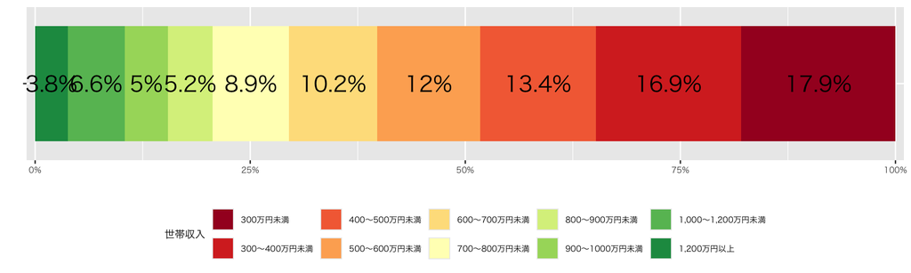

## 人生は自分の思い通りになるか（主要6カ国：世帯収入・世帯収入別集計）

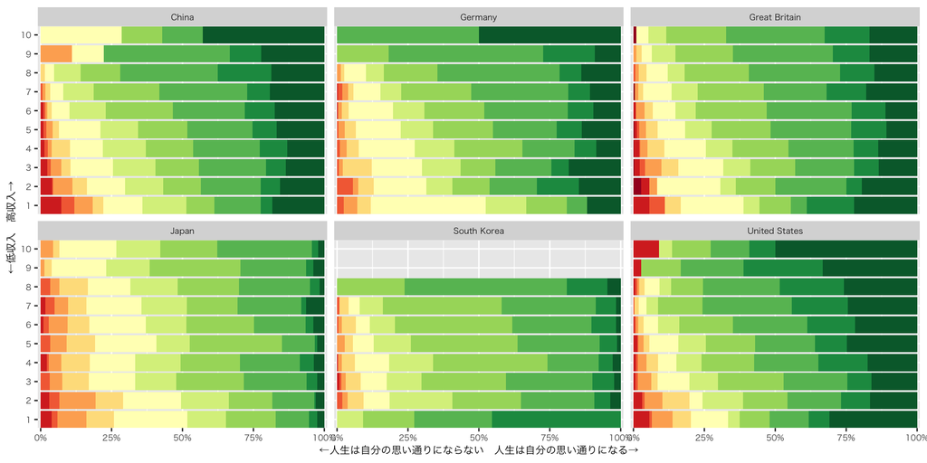

## 競争か平等か（主要6カ国：世帯収入・世帯収入別集計）

- 平等な所得を是認する者は赤色､
- 大きな所得格差を是認する者は緑色

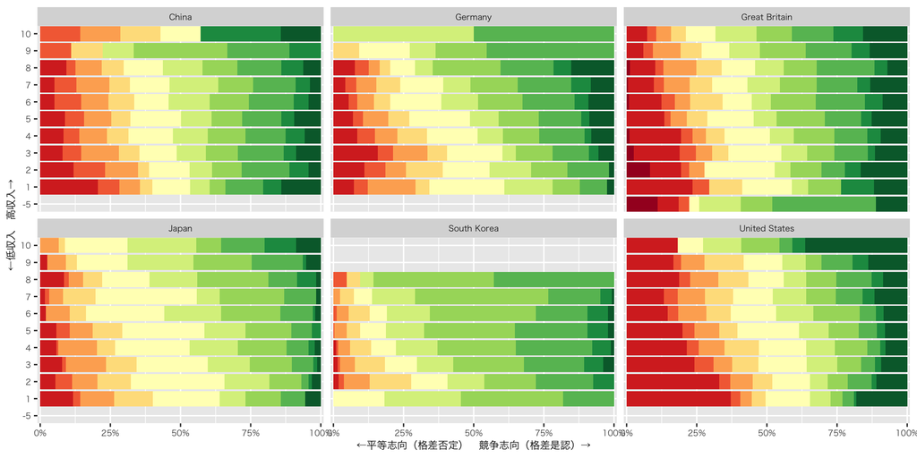

## 小さな政府志向（収入再分配機能の否定）

### 国際比較

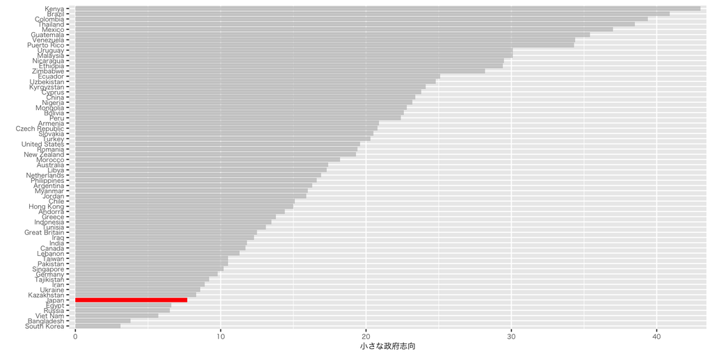

## 大きな政府志向（所得再分配機能の肯定）

### 国際比較

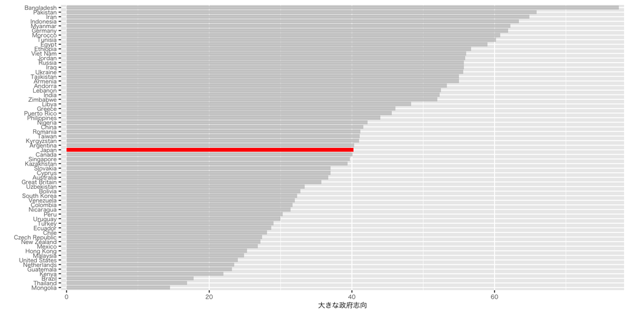

## 政府の所得再分配機能：主要6カ国比較：世帯収入別集計

### Q. 政府が富裕層に課税し、貧困層に補助金を支給することは

1. 民主主義の本質的な特徴ではない（赤色）
2. 民主主義の本質的な特徴である（緑色）

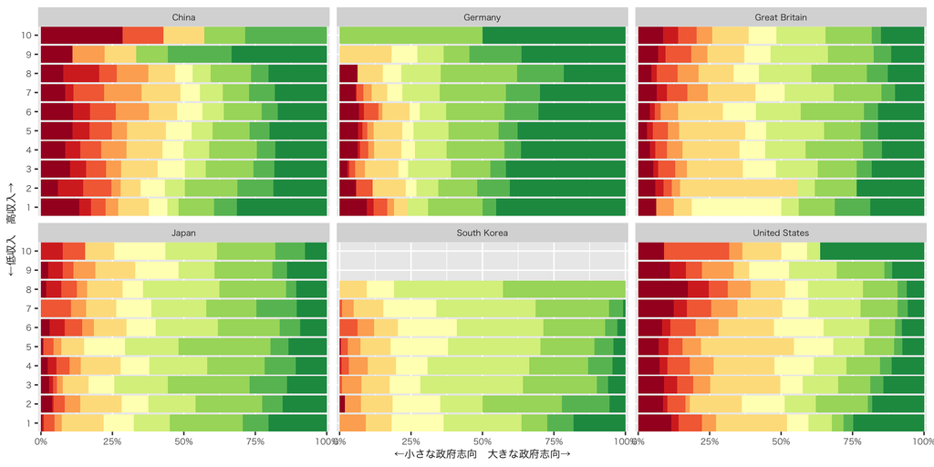

## 政治に関心あり

### 国際比較

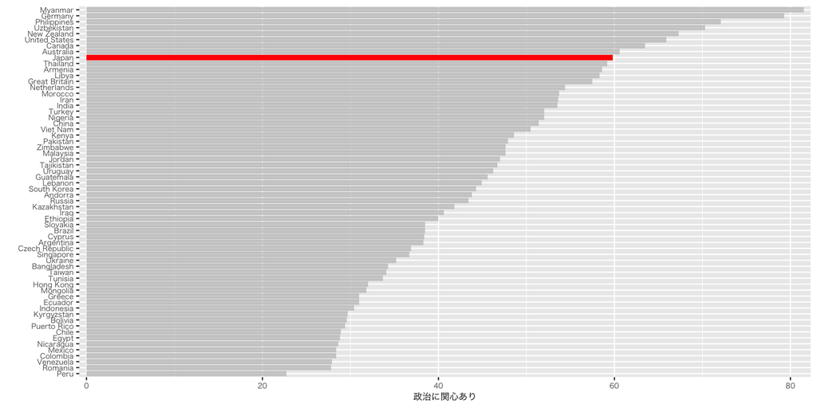

## 政治に関心なし

### 国際比較

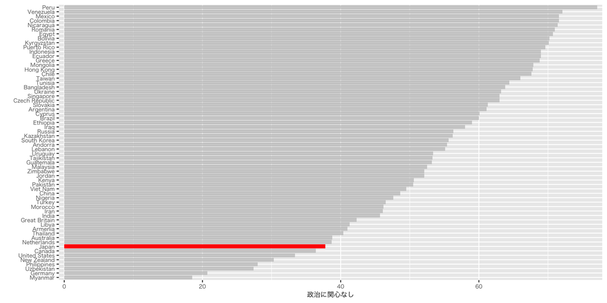

## 政治的関心の有無（主要6カ国比較・世帯収入別集計）

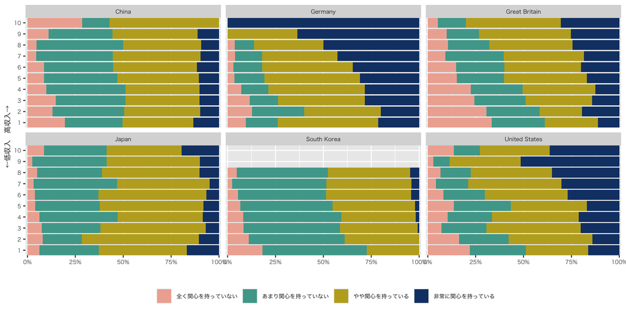

## 政治について話す機会（主要6カ国比較・世帯収入別集計）

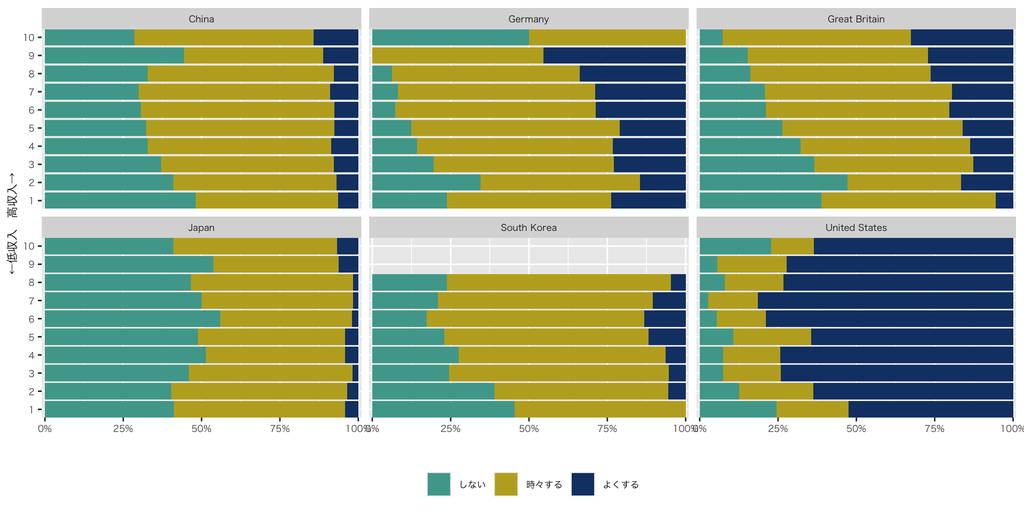

# 国際政治学

## キーワード

- 国際；主権；国際社会；主権国家体制；国際共同体；世界市民主義；現実主義

## 近年の日本外交

### 1. 安倍外交

- 「地球儀を俯瞰する」外交
  - https://www.kantei.go.jp/jp/feature/gaikou/index.html
- 「自由で開かれたインド太平洋」
  - https://www.nhk.or.jp/politics/articles/feature/62725.html
- 例：対韓輸出規制
  - https://digital.asahi.com/articles/ASQ5Y6SRDQ5CULZU00S.html
- 岩田記者（元NHK）「得意の安倍外交」

## 近年の日本外交

### 2. 岸田外交

- 核不拡散条約（NPT）再検討会議
- 広島サミット

## 「太平洋戦争」

- 主権の喪失と回復
- サンフランシスコ平和条約
- 1951年9月8日調印
- 1952年4月28日発効
- → 7年間の占領統治終了
  - 加藤陽子（2016）『それでも、日本人は「戦争」を選んだ』新潮社
  - 半藤一利（2006）『日本のいちばん長い日』文藝春秋（文春文庫）
  - 宮崎駿（ジブリ）；富野由悠季（ガンダム）

## 核戦争

[output not shown]